# Sentiment Analysis on the Literary Works of Oscar Wilde

Oscar Wilde is one of my favourite authors ever. 'The Portrait of Dorian Gray' remains as one of the stories that resonated and impacted me the most. As such, it's only natural for me to want to investigate them through some data science techniques.

Some initial questions I'd want to answer are:

- What are the most commonly used words used by Oscar Wilde?
- What is the overall sentiment present in his works?
- How does the sentiment change (if at all) from chapter to chapter? Is there a particular structure that is present?

I'll write some code to download his works from [Project Gutenberg](https://www.gutenberg.org/). These routines should be readily applicable to get stuff from other authors too!

With that said let's get started!

## Modules used in this work

The following modules were used to get this project done

```python
#Modules for downloading stuff off Project Gutenberg
import os, requests
from os.path import basename
from os.path import join
from os import makedirs
from urllib.request import urlopen
from urllib.parse import urljoin
from concurrent.futures import ThreadPoolExecutor
from concurrent.futures import as_completed
from bs4 import BeautifulSoup
import re

#Stuff for general sentiment analysis
import nltk
from nltk.corpus import twitter_samples,stopwords
from nltk.tag import pos_tag
from nltk.stem.wordnet import WordNetLemmatizer
from nltk.tokenize import word_tokenize, sent_tokenize,
from nltk import FreqDist, classify, NaiveBayesClassifier

#More stuff for sentiment analysis
nltk.download('punkt') #Pretrained model to tokenize words
nltk.download('wordnet') #Lexical database to help determine base word
nltk.download('averaged_perceptron_tagger') #Used to determine context of word in sentence
nltk.download('omw-1.4')
nltk.download('stopwords')

#Stuff for VADER
nltk.download('vader_lexicon')
from nltk.sentiment.vader import SentimentIntensityAnalyzer

#Stuff for dealing with strings and regular expressions
import re, string, random

#General modules
import matplotlib.pyplot as plt
```

## Prelude -- Communicating With Project Gutenberg

The first thing I'll need is a way to retrieve the contents from the HTML site of Project Gutenberg. This means I'll need to communicate with the site/server which I can readily do with the `urlopen` function. The URL that I'm trying to connect to is associated with a search query for 'Oscar Wilde' and it looks as follows:

`https://www.gutenberg.org/ebooks/search/?query=oscar+wilde&submit_search=Search`

I'll be replacing the string to make it more general by using a formatted string of the form

`f'https://www.gutenberg.org/ebooks/search/?query={first_name}+{last_name}&submit_search=Search'`

I should note that Project Gutenberg queries are limited to 25 search results but that should be enough for this initial exploration.

```python
# download a file from a URL, returns content of downloaded file
def download_url(urlpath):
    try:
        # open a connection to the server
        with urlopen(urlpath, timeout=3) as connection:
            # read the contents of the url as bytes and return it
            return connection.read()
    except:
        return None
```

Cool, the function for generating the author first name and last name is shown below:

```python
def getFirstLastName(author_name):
    aname = author_name.lower().rsplit()
    first_name = aname[0]
    last_name = aname[1]

    return first_name, last_name

author_name = 'Oscar Wilde'
firstname, lastname = getFirstLastName(author_name)
print(firstname, lastname)
```

```
oscar wilde
```

```python
# decode downloaded html and extract all <a href=""> links
def get_urls_from_html(content):

    # decode the provided content as ascii text
    html = content.decode('utf-8')

    # parse the document as best we can
    soup = BeautifulSoup(html, 'html.parser')

    # find all all of the <a href=""> tags in the document
    atags = soup.find_all('a')

    #Get links from search query page
    #nlinks = len(atags) - 25 - 5
    #del(atags[0:5]) #Remove first six links since they don't correspond to books
    #del(atags[-nlinks:])#Remove links that aren't book results (this query displays 25 books)

    # get all links from a tags
    return [tag.get('href') for tag in atags]
```

Now that we have the links present in the search query, I need to get the book identifiers that Project Gutenberg uses. This is done via the function below which will return a list of bookIDs that we can then use to download all the books associated with the results of our search query.

```python
# return all book unique identifiers from a list of raw links
def get_book_identifiers(links):
    # define a url pattern we are looking for
    pattern = re.compile('/ebooks/[0-9]+')
    # process the list of links for those that match the pattern
    books = set()
    for link in links:
        # check of the link matches the pattern
        if not pattern.match(link):
            continue
        # extract the book id from /ebooks/nnn
        book_id = link[8:]
        # store in the set, only keep unique ids
        books.add(book_id)
    return books
```

We are almost done with the extraction prep for our books! Now that I have the bookIDs associated with the query results I can write a function that will download the book onto a directory in our computer. This is done with the function below.

```python
# download one book from project gutenberg
def download_book(book_id, save_path):
    print(save_path)
    # construct the download url
    url = f'https://www.gutenberg.org/files/{book_id}/{book_id}-0.txt'
    # download the content
    data = download_url(url)
    if data is None:
        #print(f'Failed to download {url}')
        url = f'https://www.gutenberg.org/files/{book_id}/{book_id}.txt'
        data = download_url(url)
        if data is None:
            return f'Failed to download {url}'
        else:
            # create local path
            save_file = join(save_path, f'{book_id}.txt')
            # save book to file
            with open(save_file, 'wb') as file:
                file.write(data)
            return f'Saved {save_file}'

    # create local path
    save_file = join(save_path, f'{book_id}.txt')
    # save book to file
    with open(save_file, 'wb') as file:
        file.write(data)
    return f'Saved {save_file}'
```

```python
#Get current working directory and download book into 'books' directory
cwd = os.getcwd()
book_dir = cwd + '\\' + 'books'
test = download_book('174', book_dir)
```

The result of this function is shown below where you can see there's a text file called `174.txt` in my books directory.

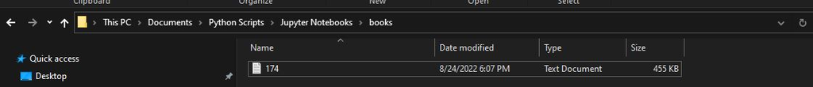

[figure not shown]

Perfect! Now that I have my base download function I can simply put my routines into a wrapper function that will allow me to download all the books present in our search query page as shown below.

```python
def download_all_books(url, save_path):
    # download the page that lists top books
    data = download_url(url)
    print(f'.downloaded {url}')
    # extract all links from the page
    links = get_urls_from_html(data)
    print(f'.found {len(links)} links on the page')
    # retrieve all unique book ids
    book_ids = get_book_identifiers(links)
    print(f'.found {len(book_ids)} unique book ids')
    # create the save directory if needed
    makedirs(save_path, exist_ok=True)
    # download and save each book in turn
    for book_id in book_ids:
        print(book_id)
        # download and save this book
        result = download_book(book_id, save_path)
        # report result
        print(result)
```

Let's run the function and see what we get!

```python
author_name = 'oscar wilde'
first_name, last_name = getFirstLastName(author_name)
author_url = f'https://www.gutenberg.org/ebooks/search/?query={first_name}+{last_name}&submit_search=Search'

#Get current working directory and download book into 'books' directory
cwd = os.getcwd()
book_dir = cwd + '\\' + 'books'

download_all_books(author_url, book_dir)
```

```
.downloaded https://www.gutenberg.org/ebooks/search/?query=oscar+wilde&submit_search=Search
.found 64 links on the page
.found 25 unique book ids
4078
C:\Users\vmurc\Documents\Python Scripts\Jupyter Notebooks\books
Saved C:\Users\vmurc\Documents\Python Scripts\Jupyter Notebooks\books\4078.txt
30120
C:\Users\vmurc\Documents\Python Scripts\Jupyter Notebooks\books
Saved C:\Users\vmurc\Documents\Python Scripts\Jupyter Notebooks\books\30120.txt
790
C:\Users\vmurc\Documents\Python Scripts\Jupyter Notebooks\books
Saved C:\Users\vmurc\Documents\Python Scripts\Jupyter Notebooks\books\790.txt
14522
C:\Users\vmurc\Documents\Python Scripts\Jupyter Notebooks\books
Saved C:\Users\vmurc\Documents\Python Scripts\Jupyter Notebooks\books\14522.txt
42704
C:\Users\vmurc\Documents\Python Scripts\Jupyter Notebooks\books
Saved C:\Users\vmurc\Documents\Python Scripts\Jupyter Notebooks\books\42704.txt
26950
C:\Users\vmurc\Documents\Python Scripts\Jupyter Notebooks\books
Saved C:\Users\vmurc\Documents\Python Scripts\Jupyter Notebooks\books\26950.txt
1017
C:\Users\vmurc\Documents\Python Scripts\Jupyter Notebooks\books
Saved C:\Users\vmurc\Documents\Python Scripts\Jupyter Notebooks\books\1017.txt
1339
C:\Users\vmurc\Documents\Python Scripts\Jupyter Notebooks\books
Saved C:\Users\vmurc\Documents\Python Scripts\Jupyter Notebooks\books\1339.txt
26740
C:\Users\vmurc\Documents\Python Scripts\Jupyter Notebooks\books
Saved C:\Users\vmurc\Documents\Python Scripts\Jupyter Notebooks\books\26740.txt
26494
C:\Users\vmurc\Documents\Python Scripts\Jupyter Notebooks\books
Saved C:\Users\vmurc\Documents\Python Scripts\Jupyter Notebooks\books\26494.txt
44238
C:\Users\vmurc\Documents\Python Scripts\Jupyter Notebooks\books
Failed to download https://www.gutenberg.org/files/44238/44238.txt
854
C:\Users\vmurc\Documents\Python Scripts\Jupyter Notebooks\books
Saved C:\Users\vmurc\Documents\Python Scripts\Jupyter Notebooks\books\854.txt
774
```

[output cut: 23 more lines]

```
873
C:\Users\vmurc\Documents\Python Scripts\Jupyter Notebooks\books
Saved C:\Users\vmurc\Documents\Python Scripts\Jupyter Notebooks\books\873.txt
174
C:\Users\vmurc\Documents\Python Scripts\Jupyter Notebooks\books
Saved C:\Users\vmurc\Documents\Python Scripts\Jupyter Notebooks\books\174.txt
902
C:\Users\vmurc\Documents\Python Scripts\Jupyter Notebooks\books
Saved C:\Users\vmurc\Documents\Python Scripts\Jupyter Notebooks\books\902.txt
1057
C:\Users\vmurc\Documents\Python Scripts\Jupyter Notebooks\books
Saved C:\Users\vmurc\Documents\Python Scripts\Jupyter Notebooks\books\1057.txt
844
C:\Users\vmurc\Documents\Python Scripts\Jupyter Notebooks\books
Saved C:\Users\vmurc\Documents\Python Scripts\Jupyter Notebooks\books\844.txt
```

The results of the `download_all_books` function is shown below

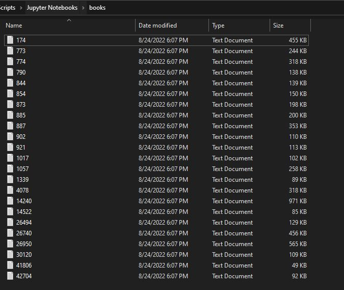

Our function returned 23 out of the 25 results that were on the search query page. The 2 results that were omitted corresponded to an audio book for the 'The Importance of Being Earnest' and the German version of 'The Portrait of Dorian Gray' which is titled 'Das Bildnis des Dorian Gray'. This is totally okay though since for my work I'm only interested in text data and documents that are in English so I'll proceed with the next stage of the process.

## Preparing the book(s) for tokenization

Now that I have the books downloaded, I'm going to write a routine to split them into Chapters.

I'll start by writing a routine to read the books we downloaded and split them into chapters.

```python
import re
book_id = '\\174.txt'          #What book are we processing?
book_name = book_dir + book_id #Location of book

#Open the book
book = open(book_name, "r", encoding="utf8")
#Assign the book a name as string
book = str(book.read())
#Use regex to split the book into chapters by finding instances of the word CHAPTER
chapters = re.split("CHAPTER ", book)
#Remove first 21 CHAPTER instances since they are just fluff
del(chapters[0:20])
#Loops for the number of chapters in the book, starting at chapter 1
for i in range(1, len(chapters)+1):
    writeBook = open("{}.txt".format(i), "w+", encoding="utf8") #Make a new book
    writeBook.write(chapters[i-1]) #Write on book with current chapter content
    writeBook.close() #Closes the book
```

Next I'll load the book chapter files that we have generated to have them accessible

```python
chapter_list = []
for file in os.listdir("."):
    if file.endswith(".txt"):
        chapter_list.append(file)

#Do a natural sort on the texts files
chapter_list.sort(key=lambda x: '{0:0>8}'.format(x).lower())
chapter_list
```

```
['1.txt',
 '2.txt',
 '3.txt',
 '4.txt',
 '5.txt',
 '6.txt',
 '7.txt',
 '8.txt',
 '9.txt',
 '10.txt',
 '11.txt',
 '12.txt',
 '13.txt',
 '14.txt',
 '15.txt',
 '16.txt',
 '17.txt',
 '18.txt',
 '19.txt',
 '20.txt',
 '21.txt']
```

I'll eventually want to place the contents from each chapter and each book into a dataframe so this is just me trying to get things in there.

```python
num_chapters = len(chapter_list)
chapter_names = []
df_list = []
i = 0
for file in chapter_list:
    chapter_name = 'Chapter ' + str(i)
    chapter_names.append(chapter_name)
    df = pd.read_csv(file,
                     sep = 'delimiter',
                     header = 0,
                     names = [chapter_name],
                     encoding='utf-8',
                     on_bad_lines='skip',
                     squeeze = True,
                     engine='python'
                    )
    df_list.append(df)
    i += 1

df_tot = pd.concat(df_list, axis =1, names = chapter_names)
df_tot
```

|  | Chapter 0 | Chapter 1 | Chapter 2 | Chapter 3 | Chapter 4 | Chapter 5 | Chapter 6 | Chapter 7 | Chapter 8 | Chapter 9 | ... | Chapter 11 | Chapter 12 | Chapter 13 | Chapter 14 | Chapter 15 | Chapter 16 | Chapter 17 | Chapter 18 | Chapter 19 | Chapter 20 |
| --- | --- | --- | --- | --- | --- | --- | --- | --- | --- | --- | --- | --- | --- | --- | --- | --- | --- | --- | --- | --- | --- |
| 0 | THE PREFACE | The studio was filled with the rich odour of r... | As they entered they saw Dorian Gray. He was s... | At half-past twelve next day Lord Henry Wotton... | One afternoon, a month later, Dorian Gray was ... | “Mother, Mother, I am so happy!” whispered the... | “I suppose you have heard the news, Basil?” sa... | For some reason or other, the house was crowde... | It was long past noon when he awoke. His valet... | As he was sitting at breakfast next morning, B... | ... | For years, Dorian Gray could not free himself ... | It was on the ninth of November, the eve of hi... | He passed out of the room and began the ascent... | At nine o’clock the next morning his servant c... | That evening, at eight-thirty, exquisitely dre... | A cold rain began to fall, and the blurred str... | A week later Dorian Gray was sitting in the co... | The next day he did not leave the house, and, ... | “There is no use your telling me that you are ... | It was a lovely night, so warm that he threw h... |
| 1 | The artist is the creator of beautiful things.... | summer wind stirred amidst the trees of the ga... | his back to them, turning over the pages of a ... | Street over to the Albany to call on his uncle... | arm-chair, in the little library of Lord Henry... | in the lap of the faded, tired-looking woman w... | evening as Hallward was shown into a little pr... | Jew manager who met them at the door was beami... | on tiptoe into the room to see if he was stirr... | into the room. | ... | this book. Or perhaps it would be more accurat... | birthday, as he often remembered afterwards. | following close behind. They walked softly, as... | chocolate on a tray and opened the shutters. D... | button-hole of Parma violets, Dorian Gray was ... | in the dripping mist. The public-houses were j... | Royal, talking to the pretty Duchess of Monmou... | time in his own room, sick with a wild terror ... | Lord Henry, dipping his white fingers into a r... | did not even put his silk scarf round his thro... |
| 2 | conceal the artist is art’s aim. The critic is... | the open door the heavy scent of the lilac, or... | “Forest Scenes.” “You must lend me these, Basi... | if somewhat rough-mannered old bachelor, whom ... | was, in its way, a very charming room, with it... | the shrill intrusive light, was sitting in the... | where dinner had been laid for three. | an oily tremulous smile. He escorted them to t... | what made his young master sleep so late. Fina... | “I am so glad I have found you, Dorian,” he sa... | ... | sought to free himself from it. He procured fr... | He was walking home about eleven o’clock from ... | night. The lamp cast fantastic shadows on the ... | peacefully, lying on his right side, with one ... | Narborough’s drawing-room by bowing servants. ... | and women were clustering in broken groups rou... | a jaded-looking man of sixty, was amongst his ... | indifferent to life itself. The consciousness ... | with rose-water. “You are quite perfect. Pray,... | smoking his cigarette, two young men in evenin... |
| 3 | into another manner or a new material his impr... | perfume of the pink-flowering thorn. | learn them. They are perfectly charming.” | selfish because it derived no particular benef... | wainscoting of olive-stained oak, its cream-co... | dingy sitting-room contained. “I am so happy!”... | “No, Harry,” answered the artist, giving his h... | pompous humility, waving his fat jewelled hand... | Victor came in softly with a cup of tea, and a... | last night, and they told me you were at the o... | ... | nine large-paper copies of the first edition, ... | had been dining, and was wrapped in heavy furs... | rising wind made some of the windows rattle. | cheek. He looked like a boy who had been tired... | throbbing with maddened nerves, and he felt wi... | of the bars came the sound of horrible laughte... | and the mellow light of the huge, lace-covered... | tracked down, had begun to dominate him. If th... | Dorian Gray shook his head. “No, Harry, I have... | heard one of them whisper to the other, “That ... |
| 4 | things. | From the corner of the divan of Persian saddle... | “That entirely depends on how you sit to-day, ... | considered generous by Society as he fed the p... | of raised plasterwork, and its brickdust felt ... | must be happy, too!” | waiter. “What is it? Nothing about politics, I... | of his voice. Dorian Gray loathed him more tha... | small tray of old Sevres china, and drew back ... | that was impossible. But I wish you had left w... | ... | different colours, so that they might suit his... | and foggy. At the corner of Grosvenor Square a... | When they reached the top landing, Dorian set ... | The man had to touch him twice on the shoulder... | manner as he bent over his hostess’s hand was ... | brawled and screamed. | table lit up the delicate china and hammered s... | tremble in the wind, he shook. The dead leaves... | things in my life. I am not going to do any mo... | remembered how pleased he used to be when he w... |
| ... | ... | ... | ... | ... | ... | ... | ... | ... | ... | ... | ... | ... | ... | ... | ... | ... | ... | ... | ... | ... | ... |
| 615 | NaN | NaN | NaN | NaN | NaN | NaN | NaN | NaN | NaN | NaN | ... | strange manners of poisoning—poisoning by a he... | NaN | NaN | NaN | NaN | NaN | NaN | NaN | NaN | NaN |
| 616 | NaN | NaN | NaN | NaN | NaN | NaN | NaN | NaN | NaN | NaN | ... | by an embroidered glove and a jewelled fan, by... | NaN | NaN | NaN | NaN | NaN | NaN | NaN | NaN | NaN |
| 617 | NaN | NaN | NaN | NaN | NaN | NaN | NaN | NaN | NaN | NaN | ... | an amber chain. Dorian Gray had been poisoned ... | NaN | NaN | NaN | NaN | NaN | NaN | NaN | NaN | NaN |
| 618 | NaN | NaN | NaN | NaN | NaN | NaN | NaN | NaN | NaN | NaN | ... | moments when he looked on evil simply as a mod... | NaN | NaN | NaN | NaN | NaN | NaN | NaN | NaN | NaN |
| 619 | NaN | NaN | NaN | NaN | NaN | NaN | NaN | NaN | NaN | NaN | ... | realize his conception of the beautiful. | NaN | NaN | NaN | NaN | NaN | NaN | NaN | NaN | NaN |

620 rows × 21 columns

Finally, I'll read the contents of the book and place them in memory here. I'll start with Chapter 1 which was saved as a file named '2.txt' since the current book has a Prelude Chapter

```python
with open('2.txt', encoding = 'utf-8') as f:
    contents = f.read().rstrip()
print(contents[0:248])
```

```
I.


The studio was filled with the rich odour of roses, and when the light
summer wind stirred amidst the trees of the garden, there came through
the open door the heavy scent of the lilac, or the more delicate
perfume of the pink-flowering thorn.
```

We are ready to roll!

## Tokenizing the Chapter

```python
chap_token = word_tokenize(contents)
del(chap_token[0:2])
chap_token[0:20]
```

```
['The',
 'studio',
 'was',
 'filled',
 'with',
 'the',
 'rich',
 'odour',
 'of',
 'roses',
 ',',
 'and',
 'when',
 'the',
 'light',
 'summer',
 'wind',
 'stirred',
 'amidst',
 'the']
```

## Tagging the words in the chapter

Now I'm going to tag each of the words in the book

```python
pos_tag(chap_token)[0:20]
```

```
[('The', 'DT'),
 ('studio', 'NN'),
 ('was', 'VBD'),
 ('filled', 'VBN'),
 ('with', 'IN'),
 ('the', 'DT'),
 ('rich', 'JJ'),
 ('odour', 'NN'),
 ('of', 'IN'),
 ('roses', 'NNS'),
 (',', ','),
 ('and', 'CC'),
 ('when', 'WRB'),
 ('the', 'DT'),
 ('light', 'JJ'),
 ('summer', 'NN'),
 ('wind', 'NN'),
 ('stirred', 'VBD'),
 ('amidst', 'IN'),
 ('the', 'DT')]
```

That worked! Every tokenized word has a tag associated with it now.

## Lemmatizing the words in the chapter

Now I'm going to lemmatize the chapter

```python
def lemmatize_sentence(tokens):
    lemmatizer = WordNetLemmatizer()
    lemmatized_sentence = []
    for word, tag in pos_tag(tokens):
        if tag.startswith('NN'):
            pos = 'n'
        elif tag.startswith('VB'):
            pos = 'v'
        else:
            pos = 'a'
        lemmatized_sentence.append(lemmatizer.lemmatize(word, pos))
    return lemmatized_sentence

lemm_chapter = lemmatize_sentence(chap_token)
lemm_chapter[0:20]
```

```
['The',
 'studio',
 'be',
 'fill',
 'with',
 'the',
 'rich',
 'odour',
 'of',
 'rose',
 ',',
 'and',
 'when',
 'the',
 'light',
 'summer',
 'wind',
 'stir',
 'amidst',
 'the']
```

Perfect! Words have been lemmatized. Notice how there is a comma token under rose. I'll remove that and other things as part of the denoising/cleanup process.

## Denoising the text

Now I'm going to denoise the chapter by removing punctuations and special quote characters

```python
stop_words = stopwords.words('english')

def remove_noise(tweet_tokens, stop_words = ()):

    cleaned_tokens = []

    for token, tag in pos_tag(tweet_tokens):

        if tag.startswith("NN"):
            pos = 'n'
        elif tag.startswith('VB'):
            pos = 'v'
        else:
            pos = 'a'

        lemmatizer = WordNetLemmatizer()
        token = lemmatizer.lemmatize(token, pos)

        if len(token) > 0 and (token == "“") or (token == "”") or (token == "’"):
            continue
        elif len(token) > 0 and token not in string.punctuation and token.lower() not in stop_words:
            cleaned_tokens.append(token.lower())

    return cleaned_tokens
```

```python
denoised_chapter = remove_noise(lemm_chapter, stop_words)
denoised_chapter[0:20]
```

```
['studio',
 'fill',
 'rich',
 'odour',
 'rise',
 'light',
 'summer',
 'wind',
 'stir',
 'amidst',
 'tree',
 'garden',
 'come',
 'open',
 'door',
 'heavy',
 'scent',
 'lilac',
 'delicate',
 'perfume']
```

## Calculating Word Density for Chapter

Nice! Now let's get the word density for Chapter 1!

```
These are the 20 most common words in Chapter 1:
[('say', 29), ('one', 27), ('know', 26), ('lord', 22), ('tell', 22), ('dorian', 22), ('basil', 21), ('henry', 20), ('like', 20), ('gray', 20), ('thing', 19), ('harry', 19), ('never', 18), ('seem', 16), ('think', 16), ('hallward', 16), ('look', 16), ('art', 14), ('good', 14), ('make', 13)]
```

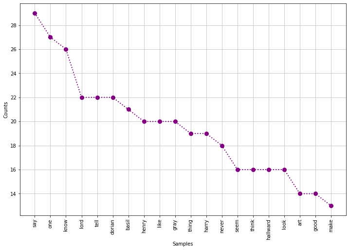

```python
freq_dist_pos = FreqDist(denoised_chapter)
print('These are the 20 most common words in Chapter 1:')
print(freq_dist_pos.most_common(20))
fig = plt.figure(figsize=(12,8))
freq_dist_pos.plot(20, cumulative=False,color = 'purple', linestyle = ':', marker='.', markersize=16)
plt.show()
```

Looks like the most common word in this chapter is 'say' with 29 instances, followed by the word 'one' with 27 instances.

## Training the Classifier

Now let's train a model! I'll use a Naive Bayes Classifier based on the twitter_samples dataset and see how that works out. I've covered this in a previous post so I'll just include the code here.

```python
#Get twitter_samples
nltk.download('twitter_samples') #30000 tweets. 5000 positive, 5000 negative. Rest are neutral.
positive_tweets = twitter_samples.strings('positive_tweets.json')
negative_tweets = twitter_samples.strings('negative_tweets.json')
text = twitter_samples.strings('tweets.20150430-223406.json')

#Clean up of all tweets
positive_tweet_tokens = twitter_samples.tokenized('positive_tweets.json')
negative_tweet_tokens = twitter_samples.tokenized('negative_tweets.json')

positive_cleaned_tokens_list = []
negative_cleaned_tokens_list = []

for tokens in positive_tweet_tokens:
    positive_cleaned_tokens_list.append(remove_noise(tokens, stop_words))

for tokens in negative_tweet_tokens:
    negative_cleaned_tokens_list.append(remove_noise(tokens, stop_words))

#Get tweets ready for modeling
def get_tweets_for_model(cleaned_tokens_list):
    for tweet_tokens in cleaned_tokens_list:
        yield dict([token, True] for token in tweet_tokens)

positive_tokens_for_model = get_tweets_for_model(positive_cleaned_tokens_list)
negative_tokens_for_model = get_tweets_for_model(negative_cleaned_tokens_list)

positive_dataset = [(tweet_dict, "Positive")
                    for tweet_dict in positive_tokens_for_model]
negative_dataset = [(tweet_dict, "Negative")
                    for tweet_dict in negative_tokens_for_model]

#Combine positive and negative tweets
dataset = positive_dataset + negative_dataset

#Shuffle generated dataset
random.shuffle(dataset)

#Do an 80:20 split on the dataset. 80 on the testing set and 20 on the training set
train_data = dataset[:2000]
test_data  = dataset[8000:]

classifier = NaiveBayesClassifier.train(train_data)

print("Accuracy is:", classify.accuracy(classifier, test_data))
print(classifier.show_most_informative_features(10))
```

```
Accuracy is: 0.9955
Most Informative Features
                     via = True           Positi : Negati =     13.7 : 1.0
                    baby = True           Negati : Positi =     12.3 : 1.0
                follower = True           Positi : Negati =     12.3 : 1.0
                  arrive = True           Positi : Negati =     10.9 : 1.0
                   enjoy = True           Positi : Negati =     10.2 : 1.0
                  friday = True           Positi : Negati =      8.6 : 1.0
                     pls = True           Negati : Positi =      8.5 : 1.0
                   thank = True           Positi : Negati =      8.4 : 1.0
                   sorry = True           Negati : Positi =      8.3 : 1.0
                      :( = None           Positi : Negati =      8.3 : 1.0
None
```

The classifier has a 99.55% accuracy. Now that I have a trained classifier, let's apply it to our chapter!

## Applying the Clasifier to the chapter

```python
def get_chapters_for_model(cleaned_tokens_list):
    for tweet_tokens in cleaned_tokens_list:
        yield dict([tweet_tokens, True] for token in tweet_tokens)
```

```python
print('This is the dictionary for the tokenized and denoised positive tweets')
tokens_for_model = get_chapters_for_model(denoised_chapter)
list(tokens_for_model)[:15]
```

```
This is the dictionary for the tokenized and denoised positive tweets
```

```
[{'studio': True},
 {'fill': True},
 {'rich': True},
 {'odour': True},
 {'rise': True},
 {'light': True},
 {'summer': True},
 {'wind': True},
 {'stir': True},
 {'amidst': True},
 {'tree': True},
 {'garden': True},
 {'come': True},
 {'open': True},
 {'door': True}]
```

```python
print(classifier.classify(dict([token, True] for token in tokens_for_model)))
```

```
Negative
```